# **Mobile Price Classification With Machine Learning**

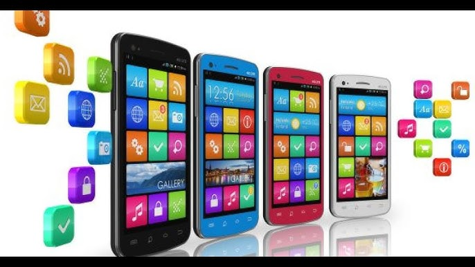

Project : Mobile Price Classification

Group No : 50

Name : Neshadi Hirunika R.K

Registration No : EG/2020/4093

Name : Fernando H.T

Registration No : EG/2021/4507

# **INTRODUCTION**

In today's highly competitive smartphone market, determining the right price for a mobile phone is crucial for both manufacturers and consumers. With numerous features and specifications available, finding a balance between functionality and cost has become a key factor in decision-making. The goal of this project is to build a machine learning model that can classify mobile phones into different price ranges based on their technical features. This can be particularly useful for manufacturers looking to position their products competitively or for customers trying to make informed purchase decisions.

By leveraging machine learning techniques, we will analyze various features such as battery power,clock speed,internal memory,mobile weight to predict the price category of a mobile phone. The insights gained from this project can help in making strategic decisions regarding pricing, feature inclusion, and product positioning in the market.

Through this project, we aim to develop a robust classification model that accurately predicts the price range of mobile phones, demonstrating the power of machine learning in real-world applications.

Dataset Link : https://www.kaggle.com/datasets/iabhishekofficial/mobile-price-classification

# **LITERATURE SURVEY**

Mobile price classification has garnered significant attention as an application of machine learning in consumer electronics. Researchers have leveraged diverse datasets and algorithms to predict mobile phone price categories based on features like hardware specifications and performance metrics. Below, we discuss notable studies that have informed this field

Feature-Based Classification : A study by researchers using the Kaggle mobile price dataset explored the application of supervised machine learning algorithms such as Decision Trees, Random Forest, and K-Nearest Neighbors (KNN). It highlighted the importance of feature selection in achieving accurate classification. The Decision Tree algorithm achieved a 75.75% accuracy, while the Random Forest and KNN models reached higher accuracy levels of 87% and 92.75%, respectively. This study emphasized the role of feature engineering in improving model predictions

https://ceur-ws.org/Vol-3682/Paper5.pdf

https://ijisrt.com/assets/upload/files/IJISRT22JAN380.pdf

Comparative Analysis of Algorithms : Another study compared the performance of advanced classifiers, including Support Vector Machines (SVM) and Logistic Regression, alongside traditional algorithms like Naïve Bayes. The research showed that SVM performed particularly well due to its ability to handle complex decision boundaries, making it ideal for non-linear feature spaces. The study underlined the significance of hyperparameter tuning to optimize classifier performance

https://ieeexplore.ieee.org/document/9604550

Feature Engineering Techniques : Recent work on mobile price classification delved into feature engineering techniques to enhance data quality and relevance. Attributes such as pixel resolution, battery capacity, and RAM were identified as highly correlated with mobile prices. This study used correlation analysis and feature importance scoring to refine input data for better prediction accuracy. These methods contributed to an improvement in classification outcomes, as demonstrated in experiments using Random Forest and Gradient Boosting classifiers

https://ieeexplore.ieee.org/document/9604550

Real-World Application and Scalability : Practical implementations of price classification models have also been explored, showing their applicability in e-commerce and mobile retail industries. By predicting price categories based on user-selected features, such models aid consumers in decision-making while enabling businesses to optimize pricing strategies

https://ijisrt.com/assets/upload/files/IJISRT22JAN380.pdf

Feature Engineering for Mobile Price Prediction : Research has demonstrated the importance of feature selection in mobile price prediction. Studies by Karur and Balaje (2021) emphasize utilizing features like battery power, RAM, processor speed, camera resolution, and display size for accurate price classification. These features were found to have a significant correlation with mobile price categories STM JOURNALS  www.irjmets.com/uploadedfiles/paper/volume3/issue_6_june_2021/12265/1628083492.pdf

Application of Decision Trees and KNN : Decision trees and K-Nearest Neighbors (KNN) have been applied successfully in mobile price classification. A study by Singh et al. (2022) concluded that decision trees performed better for classification tasks on structured datasets like mobile prices. Meanwhile, KNN's simplicity is noted, although it often lags in performance for larger datasets  www.irjmets.com/uploadedfiles/paper/volume3/issue_6_june_2021/12265/1628083492.pdf

Comparative Analysis of Machine Learning Algorithms : Suganyadevi et al. reviewed several classification algorithms, noting that logistic regression often outperformed methods like SVM and Random Forest in accuracy for mobile price datasets, particularly when the features were well-defined and normalized

https://journals.stmjournals.com/joaira/article=2024/view=155857/

www.irjmets.com/uploadedfiles/paper/volume3/issue_6_june_2021/12265/1628083492.pdf

Integration of Ensemble Learning Techniques : Recent studies have incorporated ensemble methods like Random Forests and Gradient Boosting Machines. These methods improve accuracy and generalization, especially on unbalanced datasets, as noted in studies like those by Dev et al. (2023)

 https://journals.stmjournals.com/joaira/article=2024/view=155857/

Use of Deep Learning Approaches : Deep learning is emerging as a tool for mobile price prediction. Jose et al. (2023) highlighted the use of neural networks for capturing non-linear relationships in mobile price data. However, the computational cost and data requirements remain a challenge

https://journals.stmjournals.com/joaira/article=2024/view=155857/

www.irjmets.com/uploadedfiles/paper/volume3/issue_6_june_2021/12265/1628083492.pdf

Practical Implications for the Industry : Research by Asim and Khan (2018) showcased how mobile price predictions help manufacturers design budget-friendly products and enable customers to make informed buying decisions. This study reinforced the importance of accurate models for strategic pricing

https://journals.stmjournals.com/joaira/article=2024/view=155857/

www.irjmets.com/uploadedfiles/paper/volume3/issue_6_june_2021/12265/1628083492.pdf

Insights from Exploratory Data Analysis (EDA) : Analysis techniques such as correlation matrices and feature impact graphs provide essential insights into data distribution and relationships. For instance, higher RAM and internal memory were consistently linked with premium price ranges

www.irjmets.com/uploadedfiles/paper/volume3/issue_6_june_2021/12265/1628083492.pdf

# **DATASET DESCRIPTION**

In the competitive mobile phone market, companies aim to analyze sales data to understand the factors influencing mobile phone prices. The goal is to identify the relationship between various features of a mobile phone (e.g., Battery Power, Internal Memory, Clock Speed etc.) and its price range. Instead of predicting the exact price, the focus is on classifying the phones into different price ranges based on their features (0-low price, 1- medium price, 2- high price and 3- very high price)

In our dataset altogether 20 features are available with 7 categorical features and 13 numerical features.Instead of 20 features there is a categorical feature called Price_Range which is the target variable (feature) of our dataset.Altogether 2000 enties are included for the dataset

Features Description

id : ID

battery_power : Total energy a battery can store in one time measured in mAh

blue : Has bluetooth or not

clock_speed : Speed at which microprocessor executes instructions

dual_sim : Has dual sim support or not

fc : Front Camera mega pixels

four_g : Has 4G or not

int_memory : Internal Memory in Gigabytes

m_dep : Mobile Depth in cm

mobile_wt : Weight of mobile phone

n_cores : Number of cores of processor

pc : Primary Camera mega pixels

px_height : Pixel Resolution Height

px_width : Pixel Resolution Width

ram : Random Access Memory in Megabytes

sc_h : Screen Height of mobile in cm

sc_w : Screen Width of mobile in cm

three_g : Has 3G or not

touch_screen : Has touch screen or not wifi : Has wifi or not

price_range (Target)

0 : low cost

1 : medium cost

2 : high cost

3 : very high cost

## Mount Gogle Drive

```python
from google.colab import drive
drive.mount('/content/drive')
```

## Importing Libraries

```python
import numpy as np
import pandas as pd
import os
import matplotlib.pyplot as plt
import seaborn as sns
from sklearn.ensemble import RandomForestClassifier
from sklearn.svm import SVC
```

## Importing Dataset

```python
#Load data as a pandas dataframe
df = pd.read_csv("/content/drive/MyDrive/MobilePriceClassification/train.csv")
df.head() # To display the first five rows in data set
```

|  | battery_power | blue | clock_speed | dual_sim | fc | four_g | int_memory | m_dep | mobile_wt | n_cores | ... | px_height | px_width | ram | sc_h | sc_w | talk_time | three_g | touch_screen | wifi | price_range |
| --- | --- | --- | --- | --- | --- | --- | --- | --- | --- | --- | --- | --- | --- | --- | --- | --- | --- | --- | --- | --- | --- |
| 0 | 842 | 0 | 2.2 | 0 | 1 | 0 | 7 | 0.6 | 188 | 2 | ... | 20 | 756 | 2549 | 9 | 7 | 19 | 0 | 0 | 1 | 1 |
| 1 | 1021 | 1 | 0.5 | 1 | 0 | 1 | 53 | 0.7 | 136 | 3 | ... | 905 | 1988 | 2631 | 17 | 3 | 7 | 1 | 1 | 0 | 2 |
| 2 | 563 | 1 | 0.5 | 1 | 2 | 1 | 41 | 0.9 | 145 | 5 | ... | 1263 | 1716 | 2603 | 11 | 2 | 9 | 1 | 1 | 0 | 2 |
| 3 | 615 | 1 | 2.5 | 0 | 0 | 0 | 10 | 0.8 | 131 | 6 | ... | 1216 | 1786 | 2769 | 16 | 8 | 11 | 1 | 0 | 0 | 2 |
| 4 | 1821 | 1 | 1.2 | 0 | 13 | 1 | 44 | 0.6 | 141 | 2 | ... | 1208 | 1212 | 1411 | 8 | 2 | 15 | 1 | 1 | 0 | 1 |

5 rows × 21 columns

# Exploratory Data Analysis (EDA)

```python
# Print the shape of the dataframe
df.shape
```

```
(2000, 21)
```

```python
#Print a concise summary of the pandas dataframe
df.info()
```

```
<class 'pandas.core.frame.DataFrame'>
RangeIndex: 2000 entries, 0 to 1999
Data columns (total 21 columns):
 #   Column         Non-Null Count  Dtype
---  ------         --------------  -----
 0   battery_power  2000 non-null   int64
 1   blue           2000 non-null   int64
 2   clock_speed    2000 non-null   float64
 3   dual_sim       2000 non-null   int64
 4   fc             2000 non-null   int64
 5   four_g         2000 non-null   int64
 6   int_memory     2000 non-null   int64
 7   m_dep          2000 non-null   float64
 8   mobile_wt      2000 non-null   int64
 9   n_cores        2000 non-null   int64
 10  pc             2000 non-null   int64
 11  px_height      2000 non-null   int64
 12  px_width       2000 non-null   int64
 13  ram            2000 non-null   int64
 14  sc_h           2000 non-null   int64
 15  sc_w           2000 non-null   int64
 16  talk_time      2000 non-null   int64
 17  three_g        2000 non-null   int64
 18  touch_screen   2000 non-null   int64
 19  wifi           2000 non-null   int64
 20  price_range    2000 non-null   int64
dtypes: float64(2), int64(19)
memory usage: 328.2 KB
```

```python
# Generate descriptive analytics for the numerical features in the dataset

df.describe()
```

|  | battery_power | blue | clock_speed | dual_sim | fc | four_g | int_memory | m_dep | mobile_wt | n_cores | ... | px_height | px_width | ram | sc_h | sc_w | talk_time | three_g | touch_screen | wifi | price_range |
| --- | --- | --- | --- | --- | --- | --- | --- | --- | --- | --- | --- | --- | --- | --- | --- | --- | --- | --- | --- | --- | --- |
| count | 2000.000000 | 2000.0000 | 2000.000000 | 2000.000000 | 2000.000000 | 2000.000000 | 2000.000000 | 2000.000000 | 2000.000000 | 2000.000000 | ... | 2000.000000 | 2000.000000 | 2000.000000 | 2000.000000 | 2000.000000 | 2000.000000 | 2000.000000 | 2000.000000 | 2000.000000 | 2000.000000 |
| mean | 1238.518500 | 0.4950 | 1.522250 | 0.509500 | 4.309500 | 0.521500 | 32.046500 | 0.501750 | 140.249000 | 4.520500 | ... | 645.108000 | 1251.515500 | 2124.213000 | 12.306500 | 5.767000 | 11.011000 | 0.761500 | 0.503000 | 0.507000 | 1.500000 |
| std | 439.418206 | 0.5001 | 0.816004 | 0.500035 | 4.341444 | 0.499662 | 18.145715 | 0.288416 | 35.399655 | 2.287837 | ... | 443.780811 | 432.199447 | 1084.732044 | 4.213245 | 4.356398 | 5.463955 | 0.426273 | 0.500116 | 0.500076 | 1.118314 |
| min | 501.000000 | 0.0000 | 0.500000 | 0.000000 | 0.000000 | 0.000000 | 2.000000 | 0.100000 | 80.000000 | 1.000000 | ... | 0.000000 | 500.000000 | 256.000000 | 5.000000 | 0.000000 | 2.000000 | 0.000000 | 0.000000 | 0.000000 | 0.000000 |
| 25% | 851.750000 | 0.0000 | 0.700000 | 0.000000 | 1.000000 | 0.000000 | 16.000000 | 0.200000 | 109.000000 | 3.000000 | ... | 282.750000 | 874.750000 | 1207.500000 | 9.000000 | 2.000000 | 6.000000 | 1.000000 | 0.000000 | 0.000000 | 0.750000 |
| 50% | 1226.000000 | 0.0000 | 1.500000 | 1.000000 | 3.000000 | 1.000000 | 32.000000 | 0.500000 | 141.000000 | 4.000000 | ... | 564.000000 | 1247.000000 | 2146.500000 | 12.000000 | 5.000000 | 11.000000 | 1.000000 | 1.000000 | 1.000000 | 1.500000 |
| 75% | 1615.250000 | 1.0000 | 2.200000 | 1.000000 | 7.000000 | 1.000000 | 48.000000 | 0.800000 | 170.000000 | 7.000000 | ... | 947.250000 | 1633.000000 | 3064.500000 | 16.000000 | 9.000000 | 16.000000 | 1.000000 | 1.000000 | 1.000000 | 2.250000 |
| max | 1998.000000 | 1.0000 | 3.000000 | 1.000000 | 19.000000 | 1.000000 | 64.000000 | 1.000000 | 200.000000 | 8.000000 | ... | 1960.000000 | 1998.000000 | 3998.000000 | 19.000000 | 18.000000 | 20.000000 | 1.000000 | 1.000000 | 1.000000 | 3.000000 |

8 rows × 21 columns

# Data Visualization

## Train-Test Split

```python
# Train test split
from sklearn.model_selection import train_test_split
#Seperate the independent and dependent variables
X=df.drop('price_range',axis=1) # axis=1 means drop the coloumn 'price_range'
y=df.price_range
X_train,X_test,y_train,y_test = train_test_split(X,y,test_size=0.20,random_state =42) #Test size is 20% , Afeter adding random_state each and evry time split is same
```

```python
# Print number of training data points
print(X_train.shape)
```

```
(1600, 20)
```

```python
# Print number of testing data points
print(X_test.shape)
```

```
(400, 20)
```

```python
# Define categorical and numerical list
categorical = []
numerical = []

# loop for
for i in X_train.columns  :
    if X_train[i].nunique () > 8 :
        numerical.append (i)
    else :
        categorical.append (i)
print ("Categorical variables : " , categorical)
print ("numerical variables : " , numerical)
```

```
Categorical variables :  ['blue', 'dual_sim', 'four_g', 'n_cores', 'three_g', 'touch_screen', 'wifi']
numerical variables :  ['battery_power', 'clock_speed', 'fc', 'int_memory', 'm_dep', 'mobile_wt', 'pc', 'px_height', 'px_width', 'ram', 'sc_h', 'sc_w', 'talk_time']
```

```python
#Describe the characteristics of the features in the train test
X_train.describe()
```

|  | battery_power | blue | clock_speed | dual_sim | fc | four_g | int_memory | m_dep | mobile_wt | n_cores | pc | px_height | px_width | ram | sc_h | sc_w | talk_time | three_g | touch_screen | wifi |
| --- | --- | --- | --- | --- | --- | --- | --- | --- | --- | --- | --- | --- | --- | --- | --- | --- | --- | --- | --- | --- |
| count | 1600.000000 | 1600.000000 | 1600.000000 | 1600.000000 | 1600.000000 | 1600.00000 | 1600.000000 | 1600.000000 | 1600.000000 | 1600.000000 | 1600.000000 | 1600.000000 | 1600.000000 | 1600.000000 | 1600.000000 | 1600.000000 | 1600.000000 | 1600.000000 | 1600.000000 | 1600.000000 |
| mean | 1240.808750 | 0.490625 | 1.513625 | 0.515000 | 4.310000 | 0.52250 | 32.270000 | 0.502562 | 140.633750 | 4.542500 | 9.878125 | 644.226250 | 1249.091875 | 2116.131250 | 12.220000 | 5.705625 | 10.956875 | 0.763125 | 0.505000 | 0.498750 |
| std | 440.727396 | 0.500068 | 0.820189 | 0.499931 | 4.339288 | 0.49965 | 18.195165 | 0.286882 | 35.338171 | 2.289972 | 6.014847 | 445.436918 | 431.530171 | 1080.711326 | 4.205372 | 4.338863 | 5.507742 | 0.425298 | 0.500131 | 0.500155 |
| min | 501.000000 | 0.000000 | 0.500000 | 0.000000 | 0.000000 | 0.00000 | 2.000000 | 0.100000 | 80.000000 | 1.000000 | 0.000000 | 0.000000 | 500.000000 | 258.000000 | 5.000000 | 0.000000 | 2.000000 | 0.000000 | 0.000000 | 0.000000 |
| 25% | 852.000000 | 0.000000 | 0.675000 | 0.000000 | 1.000000 | 0.00000 | 16.000000 | 0.200000 | 109.000000 | 3.000000 | 5.000000 | 280.000000 | 874.000000 | 1212.750000 | 9.000000 | 2.000000 | 6.000000 | 1.000000 | 0.000000 | 0.000000 |
| 50% | 1231.000000 | 0.000000 | 1.500000 | 1.000000 | 3.000000 | 1.00000 | 32.500000 | 0.500000 | 141.000000 | 4.000000 | 10.000000 | 554.500000 | 1241.500000 | 2110.500000 | 12.000000 | 5.000000 | 11.000000 | 1.000000 | 1.000000 | 0.000000 |
| 75% | 1619.000000 | 1.000000 | 2.225000 | 1.000000 | 7.000000 | 1.00000 | 48.000000 | 0.800000 | 171.000000 | 7.000000 | 15.000000 | 945.500000 | 1626.250000 | 3042.000000 | 16.000000 | 9.000000 | 16.000000 | 1.000000 | 1.000000 | 1.000000 |
| max | 1998.000000 | 1.000000 | 3.000000 | 1.000000 | 19.000000 | 1.00000 | 64.000000 | 1.000000 | 200.000000 | 8.000000 | 20.000000 | 1960.000000 | 1998.000000 | 3998.000000 | 19.000000 | 18.000000 | 20.000000 | 1.000000 | 1.000000 | 1.000000 |

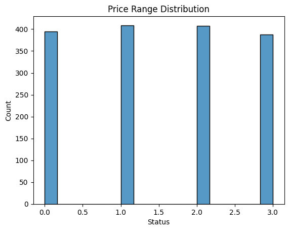

```python
# Print the counts of status (the target variable)

sns.histplot(x=y_train)
plt.title('Price Range Distribution')
plt.xlabel('Status')
plt.ylabel('Count')
plt.show()
```

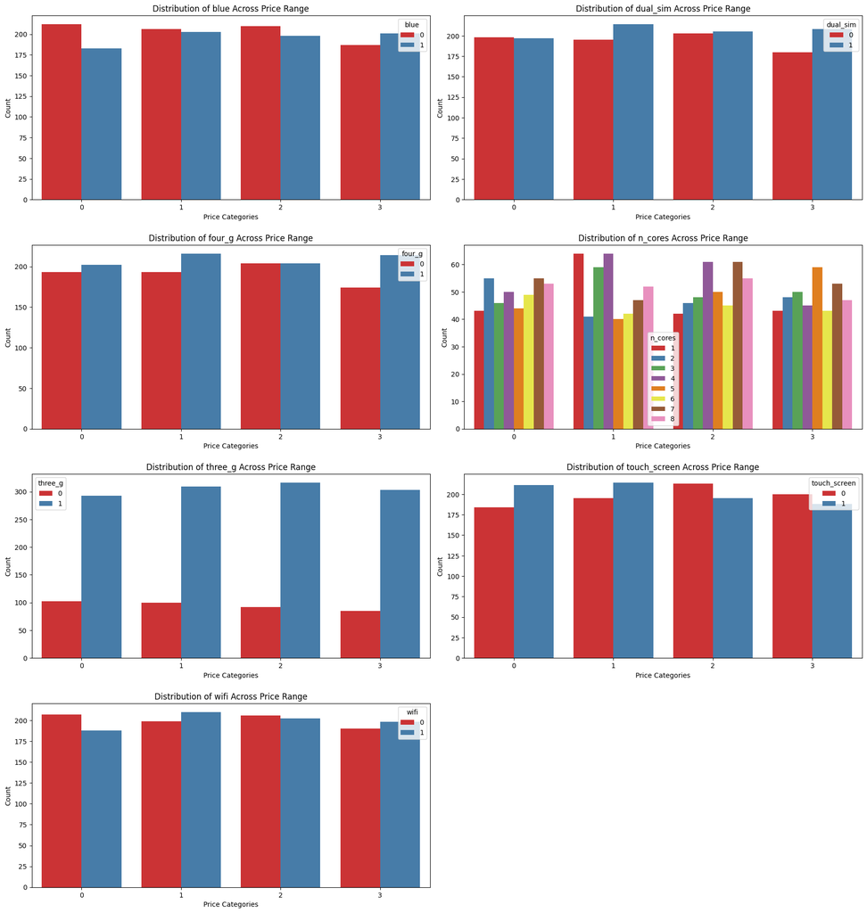

```python
import matplotlib.pyplot as plt
import seaborn as sns

categorical_columns = X_train[categorical]

# Combine the target variable with the features DataFrame for visualization
X_train_combined = X_train.copy()
X_train_combined['price_range'] = y_train  # Assuming y_train contains the target variable

# Set the size of the plots
plt.figure(figsize=(18, 28))

# Loop through each categorical column and create a count plot based on price_range
for i, col in enumerate(categorical_columns, 1):
    plt.subplot(6, 2, i)  # Adjust the grid size (6 rows, 2 columns)
    sns.countplot(data=X_train_combined, x='price_range', hue=col, palette='Set1')
    plt.title(f'Distribution of {col} Across Price Range', fontsize=12)  # Adjusted font size
    plt.xlabel('Price Categories', fontsize=10)
    plt.ylabel('Count', fontsize=10)

plt.tight_layout(h_pad=2)  # Adjusted horizontal padding
plt.show()
```

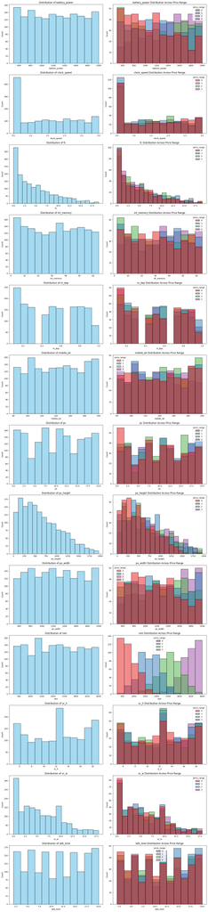

```python
import matplotlib.pyplot as plt
import seaborn as sns

numerical_columns = ['battery_power', 'clock_speed', 'fc', 'int_memory', 'm_dep', 'mobile_wt',
                     'pc', 'px_height', 'px_width', 'ram', 'sc_h', 'sc_w', 'talk_time']

# Combine the target variable with the features DataFrame for visualization
X_train_combined = X_train.copy()
X_train_combined['price_range'] = y_train

# Create subplots dynamically
n_features = len(numerical_columns)
fig, ax = plt.subplots(n_features, 2, figsize=(15, n_features * 5))  # Adjust height dynamically

# Define a custom palette
custom_palette = sns.color_palette("husl", len(X_train_combined['price_range'].unique()))

# Loop through each numerical column
for i, col in enumerate(numerical_columns):
    sns.histplot(x=col, data=X_train_combined, ax=ax[i, 0], color="skyblue")  # Plot without hue, single color
    sns.histplot(x=col, hue='price_range', data=X_train_combined, ax=ax[i, 1], palette='Set1')  # Plot with hue, custom palette

    # Set titles and labels for clarity
    ax[i, 0].set(title=f'Distribution of {col}', xlabel=col, ylabel='Count')
    ax[i, 1].set(title=f'{col} Distribution Across Price Range', xlabel=col, ylabel='Count')

# Adjust layout to ensure no overlap
plt.tight_layout()
plt.show()
```

## Missing/Null Values

```python
X_train.isnull().sum() # Check whether is there any null value indicates in training dataset
```

|  | 0 |
| --- | --- |
| battery_power | 0 |
| blue | 0 |
| clock_speed | 0 |
| dual_sim | 0 |
| fc | 0 |
| four_g | 0 |
| int_memory | 0 |
| m_dep | 0 |
| mobile_wt | 0 |
| n_cores | 0 |
| pc | 0 |
| px_height | 0 |
| px_width | 0 |
| ram | 0 |
| sc_h | 0 |
| sc_w | 0 |
| talk_time | 0 |
| three_g | 0 |
| touch_screen | 0 |
| wifi | 0 |

**dtype:** int64

```python
X_test.isnull().sum() # Check whether is there any null value indicates in testing dataset
```

|  | 0 |
| --- | --- |
| battery_power | 0 |
| blue | 0 |
| clock_speed | 0 |
| dual_sim | 0 |
| fc | 0 |
| four_g | 0 |
| int_memory | 0 |
| m_dep | 0 |
| mobile_wt | 0 |
| n_cores | 0 |
| pc | 0 |
| px_height | 0 |
| px_width | 0 |
| ram | 0 |
| sc_h | 0 |
| sc_w | 0 |
| talk_time | 0 |
| three_g | 0 |
| touch_screen | 0 |
| wifi | 0 |

**dtype:** int64

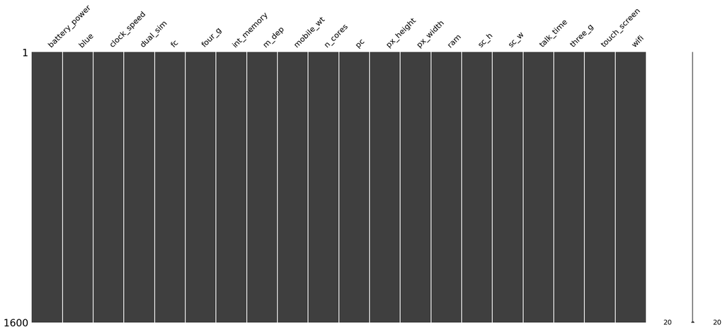

```python
# Display the missing values in the train set using matrix plot
import missingno as msno
msno.matrix(X_train)
plt.show()
```

There is no any missing/null values in both training and testing set.Therefore, Data preprocessing for missing/null values is not applicable

## Duplicate Records

```python
#Check whether is there any duplicated records for training set
X_train.duplicated()
X_train.duplicated().sum() # Check the sum of duplicated records
```

```
0
```

```python
#Check whether is there any duplicated records for testing set
X_test.duplicated()
X_test.duplicated().sum() # Check the sum of duplicated records
```

```
0
```

It is obvious that there is no any duplicated records for both training and testing data set.Therefore, Data preprocessing for duplicated record is not applicable

## Identify Outliers

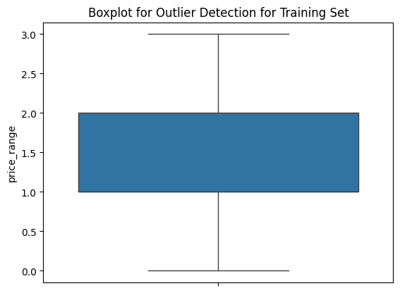

```python
import numpy as np
y_train = np.squeeze(y_train)

sns.boxplot(data=X_train, y=y_train) #Create Boxplot
plt.title("Boxplot for Outlier Detection for Training Set")
plt.show()
```

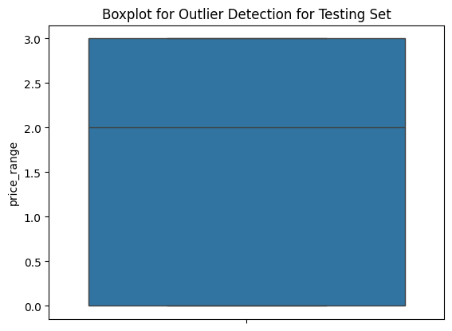

```python
import numpy as np
y_test = np.squeeze(y_test)

sns.boxplot(data=X_test, y=y_test) #Create Boxplot
plt.title("Boxplot for Outlier Detection for Testing Set")
plt.show()
```

## Identify Imbalanced Data Set

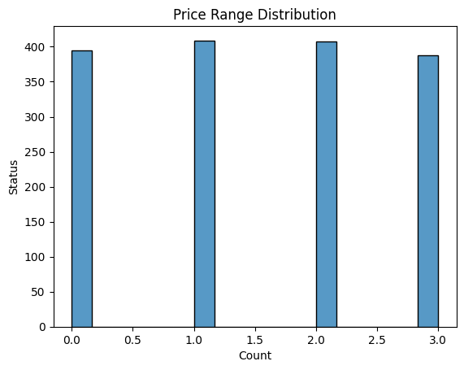

```python
# Print the counts of status (the target variable) using seaborn countplot

sns.histplot(x=y_train)
plt.title('Price Range Distribution')
plt.xlabel('Count')
plt.ylabel('Status')
plt.show()
```

According to this graph,this not reflects an unequal distribution of classes within a dataset. Therfore, not need imbalanced dataset handling

# Data Preprocessing

## Handling Categorical Variables

```python
# Encode the target variable in train and test sets

from sklearn.preprocessing import LabelEncoder
le = LabelEncoder()
y_train = pd.DataFrame(data=y_train)
y_train['price_range'] = le.fit_transform(y_train['price_range'])
y_train = y_train.reset_index(drop=True)

le1 = LabelEncoder()
y_test = pd.DataFrame(data=y_test)
y_test['price_range'] = le1.fit_transform(y_test['price_range'])
y_test = y_test.reset_index(drop=True)
```

```python
# Print the encoded labels for the training set

for i in range(4):
    print(f'Label {i}: {le.classes_[i]}')
```

```
Label 0: 0
Label 1: 1
Label 2: 2
Label 3: 3
```

## Feature Scaling for Numerical Features

```python
from sklearn.preprocessing import MinMaxScaler # Importing MinMaxScaler
numerical_variables = ['battery_power', 'clock_speed', 'fc', 'int_memory', 'm_dep', 'mobile_wt', 'pc', 'px_height', 'px_width', 'ram', 'sc_h', 'sc_w', 'talk_time']
minmax_scalar = MinMaxScaler()
X_train[numerical_variables]= minmax_scalar.fit_transform(X_train[numerical_variables]) # Feature scaling for training dataset
X_test[numerical_variables]= minmax_scalar.fit_transform(X_test[numerical_variables]) # Feature scaling for testing dataset
```

```python
X_train.head()
```

|  | battery_power | blue | clock_speed | dual_sim | fc | four_g | int_memory | m_dep | mobile_wt | n_cores | pc | px_height | px_width | ram | sc_h | sc_w | talk_time | three_g | touch_screen | wifi |
| --- | --- | --- | --- | --- | --- | --- | --- | --- | --- | --- | --- | --- | --- | --- | --- | --- | --- | --- | --- | --- |
| 968 | 0.949900 | 0 | 0.00 | 1 | 0.368421 | 0 | 0.709677 | 0.444444 | 0.925000 | 1 | 0.50 | 0.391327 | 0.840454 | 0.329144 | 0.357143 | 0.500000 | 0.055556 | 1 | 1 | 1 |
| 240 | 0.088176 | 1 | 0.68 | 0 | 0.000000 | 1 | 0.758065 | 0.000000 | 0.491667 | 8 | 0.05 | 0.269898 | 0.339786 | 0.882888 | 0.428571 | 0.055556 | 0.777778 | 1 | 1 | 1 |
| 819 | 0.490982 | 0 | 0.16 | 1 | 0.105263 | 1 | 0.887097 | 0.000000 | 0.900000 | 1 | 0.70 | 0.263776 | 0.206275 | 0.306952 | 0.642857 | 0.666667 | 1.000000 | 1 | 0 | 1 |
| 692 | 0.187041 | 0 | 0.24 | 0 | 0.105263 | 0 | 0.580645 | 0.333333 | 0.983333 | 5 | 0.35 | 0.155102 | 0.783712 | 0.868984 | 0.571429 | 0.444444 | 0.166667 | 0 | 0 | 1 |
| 420 | 0.637943 | 1 | 0.00 | 1 | 0.368421 | 0 | 0.080645 | 0.333333 | 0.208333 | 5 | 0.60 | 0.419898 | 0.403204 | 0.355348 | 0.071429 | 0.277778 | 1.000000 | 1 | 0 | 1 |

```python
X_test.head()
```

|  | battery_power | blue | clock_speed | dual_sim | fc | four_g | int_memory | m_dep | mobile_wt | n_cores | pc | px_height | px_width | ram | sc_h | sc_w | talk_time | three_g | touch_screen | wifi |
| --- | --- | --- | --- | --- | --- | --- | --- | --- | --- | --- | --- | --- | --- | --- | --- | --- | --- | --- | --- | --- |
| 1860 | 0.767270 | 0 | 0.80 | 0 | 0.166667 | 1 | 0.370968 | 0.555556 | 1.000000 | 2 | 0.25 | 0.110695 | 0.740147 | 0.115066 | 0.214286 | 0.333333 | 0.500000 | 1 | 1 | 0 |
| 353 | 0.456070 | 0 | 0.00 | 0 | 0.388889 | 1 | 0.096774 | 0.444444 | 0.483333 | 8 | 0.80 | 0.144920 | 0.324649 | 0.617340 | 1.000000 | 0.944444 | 0.944444 | 1 | 0 | 0 |
| 1333 | 0.985915 | 0 | 0.96 | 0 | 0.500000 | 0 | 0.193548 | 0.333333 | 0.966667 | 7 | 0.90 | 0.154545 | 0.301937 | 0.283650 | 0.214286 | 0.055556 | 0.333333 | 1 | 1 | 0 |
| 905 | 0.326626 | 1 | 0.60 | 0 | 0.222222 | 0 | 0.241935 | 0.111111 | 0.716667 | 3 | 0.95 | 0.134759 | 0.597194 | 0.972973 | 0.928571 | 0.388889 | 0.944444 | 1 | 1 | 0 |
| 1289 | 0.075788 | 1 | 0.00 | 1 | 0.388889 | 0 | 0.903226 | 0.444444 | 0.416667 | 5 | 0.40 | 0.543850 | 0.973948 | 0.441531 | 0.642857 | 0.277778 | 0.166667 | 1 | 0 | 0 |

# Machine Learning Model Development:

## Implementing the Randon Forest model

```python
from sklearn.ensemble import RandomForestClassifier  # Importing RandomForestClassifier

rf = RandomForestClassifier(n_estimators=10, max_depth=5)  # Instance of RandomForestClassifier with 10 decision trees and max depth of 5
rf.fit(X_train, y_train.values.ravel())  # Flatten y_train to 1D array if it's a DataFrame
```

```
RandomForestClassifier(max_depth=5, n_estimators=10)
```

## Model Evaluation for Random Forest Classifier

```python
accuracy = rf.score(X_train,y_train) # Print the accuracy of training dataset
print("Accuracy is",accuracy)
```

```
Accuracy is 0.8475
```

```python
accuracy = rf.score(X_test,y_test) # Print the accuracy of testing dataset
print("Accuracy is",accuracy)
```

```
Accuracy is 0.755
```

## Cross Validation for Random Forest Classifier

```python
from sklearn.model_selection import cross_validate
from sklearn.ensemble import RandomForestClassifier

rf_cv = RandomForestClassifier(n_estimators=10, max_depth=5)  # Instance of RandomForestClassifier with 10 decision trees and max depth of 5

# Perform cross-validation, ensuring y_train is 1D
cv_results = cross_validate(rf_cv, X_train, y_train.values.ravel(), scoring='accuracy', cv=5)

# Print the cross-validation scores
print(cv_results['test_score'])
```

```
[0.709375 0.75625  0.715625 0.73125  0.78125 ]
```

## Cross Validated Model Evaluation

```python
rf_cv.fit(X_train, y_train.values.ravel())  # Flatten y_train to 1D array if it's a DataFrame
```

```
RandomForestClassifier(max_depth=5, n_estimators=10)
```

```python
rf_cv.score(X_train,y_train)  # Calculate and print the accuracy on the training data
```

```
0.8325
```

```python
rf.score(X_test,y_test) # Calculate and print the accuracy on the testing data
```

```
0.755
```

## Grid Search CV for Random Forest Classifier

```python
from sklearn.model_selection import GridSearchCV
rfc = RandomForestClassifier()
# Define parameter grid
forest_params = [{'max_depth': list(range(10, 15)), 'max_features': list(range(1, 14))}]

# GridSearchCV setup
clf = GridSearchCV(rfc, forest_params, cv=5, scoring='accuracy', verbose=3)

# Ensure the target variable is a 1D array
y_train_1d = y_train.values.ravel()  # Convert to 1D array

# Fit the GridSearchCV
clf.fit(X_train, y_train_1d)
```

```
Fitting 5 folds for each of 65 candidates, totalling 325 fits
[CV 1/5] END ......max_depth=10, max_features=1;, score=0.716 total time=   0.4s
[CV 2/5] END ......max_depth=10, max_features=1;, score=0.756 total time=   0.3s
[CV 3/5] END ......max_depth=10, max_features=1;, score=0.697 total time=   0.3s
[CV 4/5] END ......max_depth=10, max_features=1;, score=0.669 total time=   0.3s
[CV 5/5] END ......max_depth=10, max_features=1;, score=0.631 total time=   0.3s
[CV 1/5] END ......max_depth=10, max_features=2;, score=0.781 total time=   0.3s
[CV 2/5] END ......max_depth=10, max_features=2;, score=0.850 total time=   0.3s
[CV 3/5] END ......max_depth=10, max_features=2;, score=0.809 total time=   0.3s
[CV 4/5] END ......max_depth=10, max_features=2;, score=0.769 total time=   0.3s
[CV 5/5] END ......max_depth=10, max_features=2;, score=0.794 total time=   0.3s
[CV 1/5] END ......max_depth=10, max_features=3;, score=0.878 total time=   0.4s
[CV 2/5] END ......max_depth=10, max_features=3;, score=0.866 total time=   0.4s
[CV 3/5] END ......max_depth=10, max_features=3;, score=0.850 total time=   0.4s
[CV 4/5] END ......max_depth=10, max_features=3;, score=0.831 total time=   0.3s
[CV 5/5] END ......max_depth=10, max_features=3;, score=0.838 total time=   0.4s
[CV 1/5] END ......max_depth=10, max_features=4;, score=0.875 total time=   0.6s
[CV 2/5] END ......max_depth=10, max_features=4;, score=0.900 total time=   0.6s
[CV 3/5] END ......max_depth=10, max_features=4;, score=0.853 total time=   0.6s
[CV 4/5] END ......max_depth=10, max_features=4;, score=0.841 total time=   0.6s
[CV 5/5] END ......max_depth=10, max_features=4;, score=0.844 total time=   0.6s
[CV 1/5] END ......max_depth=10, max_features=5;, score=0.903 total time=   0.7s
[CV 2/5] END ......max_depth=10, max_features=5;, score=0.909 total time=   0.7s
[CV 3/5] END ......max_depth=10, max_features=5;, score=0.884 total time=   0.7s
[CV 4/5] END ......max_depth=10, max_features=5;, score=0.859 total time=   0.4s
[CV 5/5] END ......max_depth=10, max_features=5;, score=0.853 total time=   0.4s
[CV 1/5] END ......max_depth=10, max_features=6;, score=0.878 total time=   0.5s
[CV 2/5] END ......max_depth=10, max_features=6;, score=0.909 total time=   0.5s
[CV 3/5] END ......max_depth=10, max_features=6;, score=0.897 total time=   0.5s
[CV 4/5] END ......max_depth=10, max_features=6;, score=0.863 total time=   0.5s
[CV 5/5] END ......max_depth=10, max_features=6;, score=0.853 total time=   0.5s
[CV 1/5] END ......max_depth=10, max_features=7;, score=0.866 total time=   0.5s
[CV 2/5] END ......max_depth=10, max_features=7;, score=0.903 total time=   0.5s
[CV 3/5] END ......max_depth=10, max_features=7;, score=0.878 total time=   0.5s
[CV 4/5] END ......max_depth=10, max_features=7;, score=0.856 total time=   0.5s
[CV 5/5] END ......max_depth=10, max_features=7;, score=0.859 total time=   0.5s
[CV 1/5] END ......max_depth=10, max_features=8;, score=0.897 total time=   0.5s
[CV 2/5] END ......max_depth=10, max_features=8;, score=0.900 total time=   0.5s
[CV 3/5] END ......max_depth=10, max_features=8;, score=0.897 total time=   0.5s
[CV 4/5] END ......max_depth=10, max_features=8;, score=0.838 total time=   0.5s
```

[output cut: 271 more lines]

```
[CV 1/5] END .....max_depth=14, max_features=11;, score=0.909 total time=   0.7s
[CV 2/5] END .....max_depth=14, max_features=11;, score=0.906 total time=   0.7s
[CV 3/5] END .....max_depth=14, max_features=11;, score=0.897 total time=   0.6s
[CV 4/5] END .....max_depth=14, max_features=11;, score=0.878 total time=   0.7s
[CV 5/5] END .....max_depth=14, max_features=11;, score=0.884 total time=   0.7s
[CV 1/5] END .....max_depth=14, max_features=12;, score=0.897 total time=   0.7s
[CV 2/5] END .....max_depth=14, max_features=12;, score=0.891 total time=   0.7s
[CV 3/5] END .....max_depth=14, max_features=12;, score=0.897 total time=   0.7s
[CV 4/5] END .....max_depth=14, max_features=12;, score=0.878 total time=   0.7s
[CV 5/5] END .....max_depth=14, max_features=12;, score=0.891 total time=   0.7s
[CV 1/5] END .....max_depth=14, max_features=13;, score=0.906 total time=   0.7s
[CV 2/5] END .....max_depth=14, max_features=13;, score=0.903 total time=   0.9s
[CV 3/5] END .....max_depth=14, max_features=13;, score=0.884 total time=   1.0s
[CV 4/5] END .....max_depth=14, max_features=13;, score=0.884 total time=   1.0s
[CV 5/5] END .....max_depth=14, max_features=13;, score=0.881 total time=   1.1s
```

```
GridSearchCV(cv=5, estimator=RandomForestClassifier(),
             param_grid=[{'max_depth': [10, 11, 12, 13, 14],
                          'max_features': [1, 2, 3, 4, 5, 6, 7, 8, 9, 10, 11,
                                           12, 13]}],
             scoring='accuracy', verbose=3)
```

## Grid Searched Model Evaluation

```python
# Retrieve the best parameters and score
print("Best Parameters:", clf.best_params_)
print("Best Cross-Validation Score:", clf.best_score_)
```

```
Best Parameters: {'max_depth': 11, 'max_features': 11}
Best Cross-Validation Score: 0.896875
```

```python
# Evaluate on train and test sets
print("Train Score:", clf.best_estimator_.score(X_train, y_train_1d))
print("Test Score:", clf.best_estimator_.score(X_test, y_test.values.ravel()))
```

```
Train Score: 1.0
Test Score: 0.9225
```

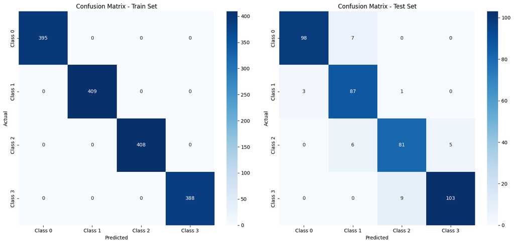

```python
from sklearn.metrics import confusion_matrix
import seaborn as sns
import matplotlib.pyplot as plt

# Best estimator (after GridSearchCV)
best_model = clf.best_estimator_

# Predict on train and test data
y_train_pred = best_model.predict(X_train)
y_test_pred = best_model.predict(X_test)

# Compute confusion matrix for train and test
train_conf_matrix = confusion_matrix(y_train_1d, y_train_pred)
test_conf_matrix = confusion_matrix(y_test.values.ravel(), y_test_pred)

# Create a figure with two subplots (1 row, 2 columns)
fig, axes = plt.subplots(1, 2, figsize=(15, 7))

# Plot confusion matrix for train data
sns.heatmap(train_conf_matrix, annot=True, fmt='d', cmap='Blues', xticklabels=['Class 0', 'Class 1', 'Class 2', 'Class 3'], yticklabels=['Class 0', 'Class 1', 'Class 2', 'Class 3'], ax=axes[0])
axes[0].set_title('Confusion Matrix - Train Set')
axes[0].set_xlabel('Predicted')
axes[0].set_ylabel('Actual')

# Plot confusion matrix for test data
sns.heatmap(test_conf_matrix, annot=True, fmt='d', cmap='Blues', xticklabels=['Class 0', 'Class 1', 'Class 2', 'Class 3'], yticklabels=['Class 0', 'Class 1', 'Class 2', 'Class 3'], ax=axes[1])
axes[1].set_title('Confusion Matrix - Test Set')
axes[1].set_xlabel('Predicted')
axes[1].set_ylabel('Actual')

plt.subplots_adjust(wspace=0.3)

# Display the plots
plt.tight_layout()
plt.show()
```

```python
from sklearn.metrics import classification_report

# Get the classification report for train and test predictions
train_class_report = classification_report(y_train_1d, y_train_pred)
test_class_report = classification_report(y_test.values.ravel(), y_test_pred)

# Print the classification reports
print("Classification Report - Train Set:\n", train_class_report)
print("Classification Report - Test Set:\n", test_class_report)
```

```
Classification Report - Train Set:
               precision    recall  f1-score   support

           0       1.00      1.00      1.00       395
           1       1.00      1.00      1.00       409
           2       1.00      1.00      1.00       408
           3       1.00      1.00      1.00       388

    accuracy                           1.00      1600
   macro avg       1.00      1.00      1.00      1600
weighted avg       1.00      1.00      1.00      1600

Classification Report - Test Set:
               precision    recall  f1-score   support

           0       0.97      0.93      0.95       105
           1       0.87      0.96      0.91        91
           2       0.89      0.88      0.89        92
           3       0.95      0.92      0.94       112

    accuracy                           0.92       400
   macro avg       0.92      0.92      0.92       400
weighted avg       0.92      0.92      0.92       400
```

## Implementing the Support Vector Machine (SVM) model

```python
from sklearn.svm import SVC  # Importing Support Vector Classifier (SVC)
svm = SVC(C=1, kernel='rbf')  # Instance of SVM with default parameters
svm.fit(X_train, y_train.values.ravel())  # Fit the SVM model to the training data
```

```
SVC(C=1)
```

## Model Evaluation for SVM

```python
accuracy = svm.score(X_train, y_train)  # Calculate accuracy on the training dataset for SVM
print("Training Accuracy is", accuracy)  # Print the training accuracy
```

```
Training Accuracy is 0.851875
```

```python
accuracy = svm.score(X_test, y_test)  # Calculate accuracy on the testing dataset for SVM
print("Testing Accuracy is", accuracy)  # Print the testing accuracy
```

```
Testing Accuracy is 0.81
```

## SVM Cross-Validation

```python
from sklearn.model_selection import cross_validate
from sklearn.svm import SVC

# Ensure y_train is a 1D array by converting it to a NumPy array and using ravel()
svm_cv = SVC(C=1, kernel='rbf')  # Instance of SVM (customizable parameters like C and kernel)

# Convert y_train to a NumPy array and flatten it with ravel()
cv_results_svm = cross_validate(svm_cv, X_train, y_train.values.ravel(), scoring='accuracy', cv=5)  # Use .values.ravel() to flatten y_train

# Print the accuracy scores for each fold
print(cv_results_svm['test_score'])  # Print the accuracy scores for each fold
```

```
[0.79375  0.765625 0.746875 0.721875 0.746875]
```

## Cross Validated Model Evaluation

## Fit the Best Estimator to the Whole Training Dataset (after cross-validation)

```python
# After cross-validation, we fit the model on the whole training dataset
svm.fit(X_train, y_train.values.ravel())  # Ensure y_train is a 1D array using .values.ravel()
```

```
SVC(C=1)
```

## Calculate the Accuracy for the Complete Training and Test Sets (after cross-validation)

```python
# Accuracy on the training data (after cross-validation)
train_accuracy = svm.score(X_train, y_train.values.ravel())
print("Training Accuracy:", train_accuracy)

# Accuracy on the test data (after cross-validation)
test_accuracy = svm.score(X_test, y_test)
print("Testing Accuracy:", test_accuracy)
```

```
Training Accuracy: 0.851875
Testing Accuracy: 0.81
```

## Grid Search CV for SVM

```python
from sklearn.svm import SVC  # Importing Support Vector Classifier (SVC)
from sklearn.model_selection import GridSearchCV

#Re-define the initial SVM model
svm = SVC()  # You can customize the default parameters here if needed

# Define the parameter grid for GridSearchCV
param_grid = {
    'C': [0.1, 1, 10],  # Regularization parameter
    'kernel': ['linear', 'rbf'],  # Kernel types
    'gamma': ['scale', 'auto']  # Gamma values for RBF kernel
}

# Perform Grid Search with Cross-Validation
grid_search = GridSearchCV(estimator=svm, param_grid=param_grid, cv=5, scoring='accuracy')
grid_search.fit(X_train, y_train.values.ravel())  # Fit GridSearchCV on the training data

# Get the best hyperparameters from GridSearchCV
best_params = grid_search.best_params_
print("Best Parameters from Grid Search:", best_params)

# Use the best estimator found by GridSearchCV
best_svm = grid_search.best_estimator_

# Fit the best estimator on the whole training dataset
best_svm.fit(X_train, y_train.values.ravel())

# Calculate the Accuracy for the Complete Training and Test Sets (after Grid Search)
train_accuracy = best_svm.score(X_train, y_train.values.ravel())  # Training accuracy
print("Training Accuracy (after Grid Search):", train_accuracy)

test_accuracy = best_svm.score(X_test, y_test)  # Testing accuracy
print("Testing Accuracy (after Grid Search):", test_accuracy)
```

```
Best Parameters from Grid Search: {'C': 10, 'gamma': 'scale', 'kernel': 'linear'}
Training Accuracy (after Grid Search): 0.976875
Testing Accuracy (after Grid Search): 0.9675
```

## Confusion Matrix

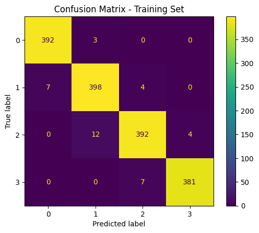

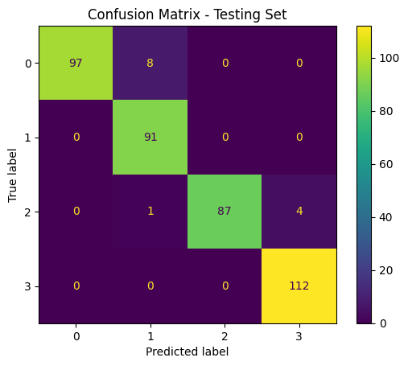

```python
from sklearn.metrics import confusion_matrix, ConfusionMatrixDisplay

# Confusion matrix for the training set
train_predictions = best_svm.predict(X_train)  # Predict on the training set
train_cm = confusion_matrix(y_train, train_predictions)  # Calculate confusion matrix


# Visualize the confusion matrix for the training set
ConfusionMatrixDisplay(confusion_matrix=train_cm).plot()
plt.title("Confusion Matrix - Training Set")
plt.show()

# Confusion matrix for the test set
test_predictions = best_svm.predict(X_test)  # Predict on the testing set
test_cm = confusion_matrix(y_test, test_predictions)  # Calculate confusion matrix


# Visualize the confusion matrix for the test set
ConfusionMatrixDisplay(confusion_matrix=test_cm).plot()
plt.title("Confusion Matrix - Testing Set")
plt.show()
```

## Classification Report

```python
from sklearn.metrics import classification_report

# Generate predictions for the training and testing datasets
train_predictions = best_svm.predict(X_train)
test_predictions = best_svm.predict(X_test)

# Training set classification report
print("Classification Report for Training Set:")
print(classification_report(y_train, train_predictions))

# Testing set classification report
print("\nClassification Report for Testing Set:")
print(classification_report(y_test, test_predictions))
```

```
Classification Report for Training Set:
              precision    recall  f1-score   support

           0       0.98      0.99      0.99       395
           1       0.96      0.97      0.97       409
           2       0.97      0.96      0.97       408
           3       0.99      0.98      0.99       388

    accuracy                           0.98      1600
   macro avg       0.98      0.98      0.98      1600
weighted avg       0.98      0.98      0.98      1600


Classification Report for Testing Set:
              precision    recall  f1-score   support

           0       1.00      0.92      0.96       105
           1       0.91      1.00      0.95        91
           2       1.00      0.95      0.97        92
           3       0.97      1.00      0.98       112

    accuracy                           0.97       400
   macro avg       0.97      0.97      0.97       400
weighted avg       0.97      0.97      0.97       400
```

# **Conclusion**

The Random Forest model seems to generalize well from the training data 100% and for test data 92.25%, with high performance across both. The slight decrease in test performance might indicate some overfitting to the training set because the difference between training accuracy and testing accuracy is grater than 5%

SVM model seems to generalize well from the training data to the test data. The model achieved a training accuracy of 97.69% and a testing accuracy of 96.75%. This suggests the model is well-trained and generalizes well to unseen data.

Both models perform well, with the Random Forest achieving 92.25% accuracy on the test set and the SVM achieving 96.75%. For training data Random Forest achieving 100% accuracy and SVM achieving 97.69%.The Random Forest has perfect training accuracy but struggles with Class 2, while the SVM shows balanced performance across all classes. Both models generalize well, but the Random Forest may need minor adjustments for Class 2, whereas the SVM is ready for deployment.

# **References**

The dataset used for this analysis, titled "Mobile Price Classification", is publicly available on Kaggle and was created by Abhishek Sharma. It contains information on various features of mobile phones, such as battery power, RAM, and screen dimensions, along with the corresponding price range classification. This dataset is frequently used for machine learning projects, including classification tasks, due to its balanced and well-structured nature. Dataset Link : https://www.kaggle.com/datasets/iabhishekofficial/mobile-price-classification/discussion?sort=hotness